[figure not shown]

# Introdução à biblioteca Pandas

- **Pandas** é uma das bibliotecas do Python mais completas para manipulação e análise de dados;
- O criador da biblioteca é [Wes McKinney](https://github.com/wesm). O nome da biblioteca faz referência ao *Panel Data* (dados em painel, tradução livre), que refere-se a um tipo especial de dados estudados na Econometria;

[figure not shown]

- Para instalar basta usar: `pip3 install pandas`;

# Documentação

- O site oficial da biblioteca é https://pandas.pydata.org/ e a documentação oficial encontra-se disponível **[aqui](https://pandas.pydata.org/docs/index.html)**;
- Uma folha de dicas para facilitar o uso do **Pandas** está disponível em [Folha de dicas](https://pandas.pydata.org/Pandas_Cheat_Sheet.pdf);
- No site oficial da biblioteca ainda disponibiliza uma [lista de comandos](https://pandas.pydata.org/pandas-docs/stable/getting_started/comparison/index.html) para os usuários de linguagens como `R`, `SQL`, `SAS` ou `STATA`, possam comparar as sintaxes dos comandos com a mesma funcionalidade no **Pandas**;

# Introdução à biblioteca Pandas

- Os principais objetos da biblioteca **Pandas** são: `Series` e `DataFrames`;
- Um objeto de tipo `Series` é uma sequência de valores que apresentam uma indexação. O objeto `Series` é comparável com o objeto `lista` do Python ou um arranjo unidimensional do **NumPy**, mas a indexação com um objeto `Series` é diferente. No **NumPy** não há muito controle sobre os índices de linha e coluna; mas com um objeto `Series`, cada elemento da série deve ter um índice, nome ou uma chave;
- O índice pode consistir em `strings`;

# Introdução à biblioteca Pandas

```python
import pandas as pd
import numpy as np

serie = pd.Series([np.nan, 1.2, -3.5, np.nan, 1, 2.8])
print(serie)
```

```
0    NaN
1    1.2
2   -3.5
3    NaN
4    1.0
5    2.8
dtype: float64
```

```python
print(type(serie), serie.values, type(serie.values), sep='\n\n')
```

```
<class 'pandas.core.series.Series'>

[ nan  1.2 -3.5  nan  1.   2.8]

<class 'numpy.ndarray'>
```

# Introdução à biblioteca Pandas

```python
dados = pd.Series(np.random.randint(0,7,size=10))
dados.value_counts()
```

```
5    4
1    3
6    2
0    1
dtype: int64
```

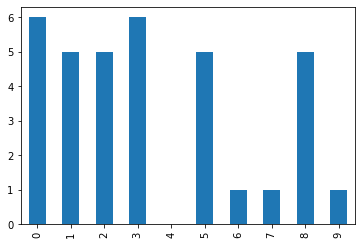

```python
_ = dados.plot(kind='bar')
```

# Introdução à biblioteca Pandas

```python
nova_serie = pd.Series(list(range(1,10,2)),
                       index=['um', 'tres', 'cinco', 'sete', 'nove'],
                       name="impares")
print(nova_serie)
```

```
um       1
tres     3
cinco    5
sete     7
nove     9
Name: impares, dtype: int64
```

```python
print(nova_serie.index)
```

```
Index(['um', 'tres', 'cinco', 'sete', 'nove'], dtype='object')
```

```python
print(nova_serie.name)
```

```
impares
```

```python
print(nova_serie.dtype)
```

```
int64
```

# Introdução à biblioteca Pandas

```python
# Podemos acessar os valores com ajuda do índices
print(nova_serie['sete'])
```

```
7
```

```python
print(nova_serie[['um', 'tres', 'sete', 'nove']])
```

```
um      1
tres    3
sete    7
nove    9
Name: impares, dtype: int64
```

```python
print(nova_serie[nova_serie > 3])
```

```
cinco    5
sete     7
nove     9
Name: impares, dtype: int64
```

```python
print(nova_serie[4])
```

```
9
```

# Introdução à biblioteca Pandas

```python
# As operações são realizadas como em arrays
print(nova_serie**2)
```

[output not shown]

```python
print(np.exp(nova_serie))
```

```
um          2.718282
tres       20.085537
cinco     148.413159
sete     1096.633158
nove     8103.083928
Name: impares, dtype: float64
```

# Introdução à biblioteca Pandas

```python
municipios = {'Serra': 527240, 'Vila Velha':501325, 'Cariacica': 383917,
              'Alegre': 29975, 'Vitória': 365855,'Castelo': 38070,
              'Iconha': 13937, 'Guarapari': 126701, 'Viana': 79500}

populacao = pd.Series(municipios, name='população')

print(populacao)
```

```
Serra         527240
Vila Velha    501325
Cariacica     383917
Alegre         29975
Vitória       365855
Castelo        38070
Iconha         13937
Guarapari     126701
Viana          79500
Name: população, dtype: int64
```

# Introdução à biblioteca Pandas

```python
print(populacao.index)
```

```
Index(['Serra', 'Vila Velha', 'Cariacica', 'Alegre', 'Vitória', 'Castelo',
       'Iconha', 'Guarapari', 'Viana'],
      dtype='object')
```

```python
populacao.index.name = 'municipios'
```

```python
print(populacao.index)
```

```
Index(['Serra', 'Vila Velha', 'Cariacica', 'Alegre', 'Vitória', 'Castelo',
       'Iconha', 'Guarapari', 'Viana'],
      dtype='object', name='municipios')
```

# Introdução à biblioteca Pandas

```python
print(populacao['Serra'])
```

```
527240
```

```python
populacao['Aracruz'] = 103101 # Adicionando a população de Aracruz
```

```python
print(populacao)
```

[output not shown]

# Introdução à biblioteca Pandas

```python
populacao['Vitória'] = np.nan # Substituindo a população de Vitória
```

```python
print(populacao)
```

```
Serra         527240.0
Vila Velha    501325.0
Cariacica     383917.0
Alegre         29975.0
Vitória            NaN
Castelo        38070.0
Iconha         13937.0
Guarapari     126701.0
Viana          79500.0
Name: população, dtype: float64
```

# Introdução à biblioteca Pandas

```python
print(pd.isnull(populacao))
```

```
Serra         False
Vila Velha    False
Cariacica     False
Alegre        False
Vitória        True
Castelo       False
Iconha        False
Guarapari     False
Viana         False
Name: população, dtype: bool
```

```python
print(populacao[pd.isnull(populacao)]) # Mostrando os valores faltantes
```

```
Vitória   NaN
Name: população, dtype: float64
```

# Introdução à biblioteca Pandas

```python
municipios2 = {'Serra': 527240, 'Vila Velha':501325, 'Cariacica': 383917,
              'Alegre': 29975, 'Vitória': 365855}

populacao2 = pd.Series(municipios2)

print(populacao2)
```

```
Serra         527240
Vila Velha    501325
Cariacica     383917
Alegre         29975
Vitória       365855
dtype: int64
```

```python
print(populacao[['Serra','Vila Velha', 'Cariacica', 'Vitória']] + populacao2)
```

```
Alegre              NaN
Cariacica      767834.0
Serra         1054480.0
Vila Velha    1002650.0
Vitória             NaN
dtype: float64
```

# Introdução à biblioteca Pandas

```python
municipios2 = {'Anchieta': 29779, 'Iúna': 29290,
               'Pinheiros': 27327, 'Ibatiba': 26426,
               'Pancas': 23306, 'Ecoporanga': 22835}

populacao2 = pd.Series(municipios2)

print('Vitória' in populacao2)
print('Vitória' in populacao)
```

```
False
True
```

# Introdução à biblioteca Pandas

```python
print(populacao.append(populacao2))
```

```
Serra         527240.0
Vila Velha    501325.0
Cariacica     383917.0
Alegre         29975.0
Vitória            NaN
Castelo        38070.0
Iconha         13937.0
Guarapari     126701.0
Viana          79500.0
Anchieta       29779.0
Iúna           29290.0
Pinheiros      27327.0
Ibatiba        26426.0
Pancas         23306.0
Ecoporanga     22835.0
dtype: float64
```

# Introdução à biblioteca Pandas

- Um `DataFrame` é uma estrutura de dados tabular, em outras palavras, representa uma tabela retangular de dados;
- Um `DataFrame` tem um índice de linha e coluna; pode ser pensado como um dicionário de `Series`, todos compartilhando o mesmo índice;

# Introdução à biblioteca Pandas

```python
# Criando um dataframe a partir de um arranjo

arranjo = np.arange(0,9).reshape(3, 3)

print(arranjo)
```

```
[[0 1 2]
 [3 4 5]
 [6 7 8]]
```

```python
print(pd.DataFrame(arranjo))
```

```
   0  1  2
0  0  1  2
1  3  4  5
2  6  7  8
```

```python
print(pd.DataFrame(arranjo,
                   columns = ['col1', 'col2','col3'],
                   index = ['linha1', 'linha2', 'linha3']))
```

```
        col1  col2  col3
linha1     0     1     2
linha2     3     4     5
linha3     6     7     8
```

# Introdução à biblioteca Pandas

```python
# Criando um dataframe a partir de uma lista de tuplas

numeros, letras = [1, 2, 3], ['a', 'b', 'c']

print(list(zip(numeros, letras)))
```

```
[(1, 'a'), (2, 'b'), (3, 'c')]
```

```python
pd.DataFrame(list(zip(numeros, letras)),
                   columns=['numeros', 'letras'])
```

|  | numeros | letras |
| --- | --- | --- |
| 0 | 1 | a |
| 1 | 2 | b |
| 2 | 3 | c |

# Introdução à biblioteca Pandas

```python
# Criando um dataframe a partir de um dicionário

pd.DataFrame({'numeros':[1, 2, 3], 'letras': ['a', 'b', 'c']},
                   columns=['numeros', 'letras'])
```

|  | numeros | letras |
| --- | --- | --- |
| 0 | 1 | a |
| 1 | 2 | b |
| 2 | 3 | c |

```python
# Atenção! As listas devem estar com o mesmo número de elementos

print(pd.DataFrame({'numeros':[1, 2, 3, 4], 'letras': ['a', 'b', 'c']},
                   columns=['numeros', 'letras']))
```

[output not shown]

# Introdução à biblioteca Pandas

```python
# Atenção! As listas devem estar com o mesmo número de elementos

pd.DataFrame({'numeros': [1, 2, 3, 4], 'letras': ['a', 'b', 'c', np.nan]},
                   columns=['numeros', 'letras'])
```

|  | numeros | letras |
| --- | --- | --- |
| 0 | 1 | a |
| 1 | 2 | b |
| 2 | 3 | c |
| 3 | 4 | NaN |

```python
# Podemos usar os métodos de NumPy

pd.DataFrame({'numeros': [1, 2, 3, 4], 'letras': ['a', 'b', 'c', np.nan]},
                   columns=['numeros', 'letras']).T
```

|  | 0 | 1 | 2 | 3 |
| --- | --- | --- | --- | --- |
| numeros | 1 | 2 | 3 | 4 |
| letras | a | b | c | NaN |

# Introdução à biblioteca Pandas

```python
# Adicionando dados com append

df = pd.DataFrame({'numeros': [1, 2, 3, 4], 'letras': ['a', 'b', 'c', np.nan]},
                   columns=['numeros', 'letras'])

df1 = df.append(pd.DataFrame({'numeros': pd.Series([5, 6]), 'letras': pd.Series(['d', 'e'])}))

df1
```

|  | numeros | letras |
| --- | --- | --- |
| 0 | 1 | a |
| 1 | 2 | b |
| 2 | 3 | c |
| 3 | 4 | NaN |
| 0 | 5 | d |
| 1 | 6 | e |

# Introdução à biblioteca Pandas

```python
df1.index = np.arange(0,6)
```

```python
df1
```

|  | numeros | letras |
| --- | --- | --- |
| 0 | 1 | a |
| 1 | 2 | b |
| 2 | 3 | c |
| 3 | 4 | NaN |
| 4 | 5 | d |
| 5 | 6 | e |

# Introdução à biblioteca Pandas

```python
# Adicionando dados com concat

df2 = pd.concat([df, pd.DataFrame({'numeros': pd.Series([5, 6]), 'letras': pd.Series(['d', 'e'])})])

df2.index = np.arange(0,6)

df2
```

|  | numeros | letras |
| --- | --- | --- |
| 0 | 1 | a |
| 1 | 2 | b |
| 2 | 3 | c |
| 3 | 4 | NaN |
| 4 | 5 | d |
| 5 | 6 | e |

# Introdução à biblioteca Pandas

```python
# Adicionando dados com concat

df2 = pd.concat([df, pd.DataFrame({'numeros': pd.Series([5, 6]),
                                   'letras': pd.Series(['d', 'e'])})], axis = 1)
df2.index.name = "Indices"
df2.columns.name = "Rótulos"

df2
```

| Rótulos Indices | numeros | letras | numeros | letras |
| --- | --- | --- | --- | --- |
| 0 | 1 | a | 5.0 | d |
| 1 | 2 | b | 6.0 | e |
| 2 | 3 | c | NaN | NaN |
| 3 | 4 | NaN | NaN | NaN |

# Introdução à biblioteca Pandas

```python
df
```

|  | numeros | letras |
| --- | --- | --- |
| 0 | 1 | a |
| 1 | 2 | b |
| 2 | 3 | c |
| 3 | 4 | NaN |

```python
print(df['numeros'], df['letras'], sep='\n\n')
```

```
0    1
1    2
2    3
3    4
Name: numeros, dtype: int64

0      a
1      b
2      c
3    NaN
Name: letras, dtype: object
```

# Introdução à biblioteca Pandas

```python
print(df.numeros, df.letras, sep='\n\n')
```

```
0    1
1    2
2    3
3    4
Name: numeros, dtype: int64

0      a
1      b
2      c
3    NaN
Name: letras, dtype: object
```

# Introdução à biblioteca Pandas

```python
df
```

|  | numeros | letras |
| --- | --- | --- |
| 0 | 1 | a |
| 1 | 2 | b |
| 2 | 3 | c |
| 3 | 4 | NaN |

```python
df.columns
```

```
Index(['numeros', 'letras'], dtype='object')
```

```python
df.loc[3]
```

```
numeros      4
letras     NaN
Name: 3, dtype: object
```

```python
df.loc[3][0]
```

```
4
```

# Introdução à biblioteca Pandas

```python
df = pd.DataFrame(np.arange(9).reshape((3, 3)), index=['a', 'c', 'd'],
                  columns=['Col1', 'Col2', 'Col3'])
df
```

|  | Col1 | Col2 | Col3 |
| --- | --- | --- | --- |
| a | 0 | 1 | 2 |
| c | 3 | 4 | 5 |
| d | 6 | 7 | 8 |

```python
# Mostrando os valores nas colunas fixando o índice
df.iloc[0]
```

```
Col1    0
Col2    1
Col3    2
Name: a, dtype: int64
```

```python
# Mostrando os valores nas colunas fixando o índice
df.loc['a']
```

```
Col1    0
Col2    1
Col3    2
Name: a, dtype: int64
```

# Introdução à biblioteca Pandas

```python
# Mostrando os valores na coluna Col1
df['Col1']
```

```
a    0
c    3
d    6
Name: Col1, dtype: int64
```

```python
# Mostrando o primeiro valor da colunas Col1
df['Col1']['a']
```

```
0
```

```python
# Sempre informe a coluna primeiro, ou use df['a':]['Col1']
df['a']['Col1']
```

[output not shown]

# Introdução à biblioteca Pandas

```python
df
```

|  | Col1 | Col2 | Col3 |
| --- | --- | --- | --- |
| a | 0 | 1 | 2 |
| c | 3 | 4 | 5 |
| d | 6 | 7 | 8 |

```python
df.iloc[2, [2, 0, 1]]
```

```
Col3    8
Col1    6
Col2    7
Name: d, dtype: int64
```

```python
df.loc['a',['Col2', 'Col3']]
```

```
Col2    1
Col3    2
Name: a, dtype: int64
```

# Introdução à biblioteca Pandas

```python
df
```

|  | Col1 | Col2 | Col3 |
| --- | --- | --- | --- |
| a | 0 | 1 | 2 |
| c | 3 | 4 | 5 |
| d | 6 | 7 | 8 |

```python
df.reindex(['a','b', 'c', 'd'])
```

|  | Col1 | Col2 | Col3 |
| --- | --- | --- | --- |
| a | 0.0 | 1.0 | 2.0 |
| b | NaN | NaN | NaN |
| c | 3.0 | 4.0 | 5.0 |
| d | 6.0 | 7.0 | 8.0 |

```python
df.reindex(columns=['Col1','Col2', 'Col3', 'Col4'])
```

|  | Col1 | Col2 | Col3 | Col4 |
| --- | --- | --- | --- | --- |
| a | 0 | 1 | 2 | NaN |
| c | 3 | 4 | 5 | NaN |
| d | 6 | 7 | 8 | NaN |

# Introdução à biblioteca Pandas

```python
df1 = pd.DataFrame(np.arange(12.).reshape((3, 4)), columns=list('abcd'))
df2 = pd.DataFrame(np.arange(20.).reshape((4, 5)), columns=list('abcde'))
```

```python
df1
```

|  | a | b | c | d |
| --- | --- | --- | --- | --- |
| 0 | 0.0 | 1.0 | 2.0 | 3.0 |
| 1 | 4.0 | 5.0 | 6.0 | 7.0 |
| 2 | 8.0 | 9.0 | 10.0 | 11.0 |

```python
df2
```

|  | a | b | c | d | e |
| --- | --- | --- | --- | --- | --- |
| 0 | 0.0 | 1.0 | 2.0 | 3.0 | 4.0 |
| 1 | 5.0 | 6.0 | 7.0 | 8.0 | 9.0 |
| 2 | 10.0 | 11.0 | 12.0 | 13.0 | 14.0 |
| 3 | 15.0 | 16.0 | 17.0 | 18.0 | 19.0 |

# Introdução à biblioteca Pandas

```python
df1 + df2
```

|  | a | b | c | d | e |
| --- | --- | --- | --- | --- | --- |
| 0 | 0.0 | 2.0 | 4.0 | 6.0 | NaN |
| 1 | 9.0 | 11.0 | 13.0 | 15.0 | NaN |
| 2 | 18.0 | 20.0 | 22.0 | 24.0 | NaN |
| 3 | NaN | NaN | NaN | NaN | NaN |

```python
df3 = df1.add(df2, fill_value=0)
df3
```

|  | a | b | c | d | e |
| --- | --- | --- | --- | --- | --- |
| 0 | 0.0 | 2.0 | 4.0 | 6.0 | 4.0 |
| 1 | 9.0 | 11.0 | 13.0 | 15.0 | 9.0 |
| 2 | 18.0 | 20.0 | 22.0 | 24.0 | 14.0 |
| 3 | 15.0 | 16.0 | 17.0 | 18.0 | 19.0 |

# Introdução à biblioteca Pandas

```python
# Aplicando uma função com apply

f = lambda x: x.max() - x.min()

df3.apply(f)
```

```
a    18.0
b    18.0
c    18.0
d    18.0
e    15.0
dtype: float64
```

```python
df3.apply(f, axis=1)
```

```
0     6.0
1     6.0
2    10.0
3     4.0
dtype: float64
```

# Introdução à biblioteca Pandas

```python
# Aplicando a função por linhas
def f(x):
    return pd.Series([x.min(), x.max()], index=['min', 'max'])

df3.apply(f)
```

|  | a | b | c | d | e |
| --- | --- | --- | --- | --- | --- |
| min | 0.0 | 2.0 | 4.0 | 6.0 | 4.0 |
| max | 18.0 | 20.0 | 22.0 | 24.0 | 19.0 |

```python
# Aplicando a função por colunas
df3.apply(f, axis=1)
```

|  | min | max |
| --- | --- | --- |
| 0 | 0.0 | 6.0 |
| 1 | 9.0 | 15.0 |
| 2 | 14.0 | 24.0 |
| 3 | 15.0 | 19.0 |

# Introdução à biblioteca Pandas

```python
df3
```

|  | a | b | c | d | e |
| --- | --- | --- | --- | --- | --- |
| 0 | 0.0 | 2.0 | 4.0 | 6.0 | 4.0 |
| 1 | 9.0 | 11.0 | 13.0 | 15.0 | 9.0 |
| 2 | 18.0 | 20.0 | 22.0 | 24.0 | 14.0 |
| 3 | 15.0 | 16.0 | 17.0 | 18.0 | 19.0 |

```python
df3.loc[4] = {'a':np.nan, 'b':15.5, 'c': 7.0, 'd': np.nan, 'e': 25.5}
```

```python
df3['e'][1] = np.nan
```

```python
df3
```

|  | a | b | c | d | e |
| --- | --- | --- | --- | --- | --- |
| 0 | 0.0 | 2.0 | 4.0 | 6.0 | 4.0 |
| 1 | 9.0 | 11.0 | 13.0 | 15.0 | NaN |
| 2 | 18.0 | 20.0 | 22.0 | 24.0 | 14.0 |
| 3 | 15.0 | 16.0 | 17.0 | 18.0 | 19.0 |
| 4 | NaN | 15.5 | 7.0 | NaN | 25.5 |

# Introdução à biblioteca Pandas

```python
df3
```

|  | a | b | c | d | e |
| --- | --- | --- | --- | --- | --- |
| 0 | 0.0 | 2.0 | 4.0 | 6.0 | 4.0 |
| 1 | 9.0 | 11.0 | 13.0 | 15.0 | NaN |
| 2 | 18.0 | 20.0 | 22.0 | 24.0 | 14.0 |
| 3 | 15.0 | 16.0 | 17.0 | 18.0 | 19.0 |
| 4 | NaN | 15.5 | 7.0 | NaN | 25.5 |

```python
df3.dropna(how='any', axis = 0)
```

|  | a | b | c | d | e |
| --- | --- | --- | --- | --- | --- |
| 0 | 0.0 | 2.0 | 4.0 | 6.0 | 4.0 |
| 2 | 18.0 | 20.0 | 22.0 | 24.0 | 14.0 |
| 3 | 15.0 | 16.0 | 17.0 | 18.0 | 19.0 |

# Introdução à biblioteca Pandas

```python
df3
```

|  | a | b | c | d | e |
| --- | --- | --- | --- | --- | --- |
| 0 | 0.0 | 2.0 | 4.0 | 6.0 | 4.0 |
| 1 | 9.0 | 11.0 | 13.0 | 15.0 | NaN |
| 2 | 18.0 | 20.0 | 22.0 | 24.0 | 14.0 |
| 3 | 15.0 | 16.0 | 17.0 | 18.0 | 19.0 |
| 4 | NaN | 15.5 | 7.0 | NaN | 25.5 |

```python
df3.dropna(how='any', axis = 1)
```

|  | b | c |
| --- | --- | --- |
| 0 | 2.0 | 4.0 |
| 1 | 11.0 | 13.0 |
| 2 | 20.0 | 22.0 |
| 3 | 16.0 | 17.0 |
| 4 | 15.5 | 7.0 |

# Introdução à biblioteca Pandas

```python
df3
```

|  | a | b | c | d | e |
| --- | --- | --- | --- | --- | --- |
| 0 | 0.0 | 2.0 | 4.0 | 6.0 | 4.0 |
| 1 | 9.0 | 11.0 | 13.0 | 15.0 | NaN |
| 2 | 18.0 | 20.0 | 22.0 | 24.0 | 14.0 |
| 3 | 15.0 | 16.0 | 17.0 | 18.0 | 19.0 |
| 4 | NaN | 15.5 | 7.0 | NaN | 25.5 |

```python
df3.dropna(how='all', axis = 0)
```

|  | a | b | c | d | e |
| --- | --- | --- | --- | --- | --- |
| 0 | 0.0 | 2.0 | 4.0 | 6.0 | 4.0 |
| 1 | 9.0 | 11.0 | 13.0 | 15.0 | NaN |
| 2 | 18.0 | 20.0 | 22.0 | 24.0 | 14.0 |
| 3 | 15.0 | 16.0 | 17.0 | 18.0 | 19.0 |
| 4 | NaN | 15.5 | 7.0 | NaN | 25.5 |

# Introdução à biblioteca Pandas

```python
df3
```

|  | a | b | c | d | e |
| --- | --- | --- | --- | --- | --- |
| 0 | 0.0 | 2.0 | 4.0 | 6.0 | 4.0 |
| 1 | 9.0 | 11.0 | 13.0 | 15.0 | NaN |
| 2 | 18.0 | 20.0 | 22.0 | 24.0 | 14.0 |
| 3 | 15.0 | 16.0 | 17.0 | 18.0 | 19.0 |
| 4 | NaN | 15.5 | 7.0 | NaN | 25.5 |

```python
df3 = df3.fillna(value=999)
df3
```

|  | a | b | c | d | e |
| --- | --- | --- | --- | --- | --- |
| 0 | 0.0 | 2.0 | 4.0 | 6.0 | 4.0 |
| 1 | 9.0 | 11.0 | 13.0 | 15.0 | 999.0 |
| 2 | 18.0 | 20.0 | 22.0 | 24.0 | 14.0 |
| 3 | 15.0 | 16.0 | 17.0 | 18.0 | 19.0 |
| 4 | 999.0 | 15.5 | 7.0 | 999.0 | 25.5 |

# Introdução à biblioteca Pandas

```python
df3
```

|  | a | b | c | d | e |
| --- | --- | --- | --- | --- | --- |
| 0 | 0.0 | 2.0 | 4.0 | 6.0 | 4.0 |
| 1 | 9.0 | 11.0 | 13.0 | 15.0 | 999.0 |
| 2 | 18.0 | 20.0 | 22.0 | 24.0 | 14.0 |
| 3 | 15.0 | 16.0 | 17.0 | 18.0 | 19.0 |
| 4 | 999.0 | 15.5 | 7.0 | 999.0 | 25.5 |

```python
df3 = df3.replace(999,np.nan)
df3
```

|  | a | b | c | d | e |
| --- | --- | --- | --- | --- | --- |
| 0 | 0.0 | 2.0 | 4.0 | 6.0 | 4.0 |
| 1 | 9.0 | 11.0 | 13.0 | 15.0 | NaN |
| 2 | 18.0 | 20.0 | 22.0 | 24.0 | 14.0 |
| 3 | 15.0 | 16.0 | 17.0 | 18.0 | 19.0 |
| 4 | NaN | 15.5 | 7.0 | NaN | 25.5 |

# Introdução à biblioteca Pandas

```python
df3
```

|  | a | b | c | d | e |
| --- | --- | --- | --- | --- | --- |
| 0 | 0.0 | 2.0 | 4.0 | 6.0 | 4.0 |
| 1 | 9.0 | 11.0 | 13.0 | 15.0 | NaN |
| 2 | 18.0 | 20.0 | 22.0 | 24.0 | 14.0 |
| 3 | 15.0 | 16.0 | 17.0 | 18.0 | 19.0 |
| 4 | NaN | 15.5 | 7.0 | NaN | 25.5 |

```python
df3.mean()
```

```
a    10.500
b    12.900
c    12.600
d    15.750
e    15.625
dtype: float64
```

```python
df3.median()
```

```
a    12.0
b    15.5
c    13.0
d    16.5
e    16.5
dtype: float64
```

# Introdução à biblioteca Pandas

```python
df3
```

|  | a | b | c | d | e |
| --- | --- | --- | --- | --- | --- |
| 0 | 0.0 | 2.0 | 4.0 | 6.0 | 4.0 |
| 1 | 9.0 | 11.0 | 13.0 | 15.0 | NaN |
| 2 | 18.0 | 20.0 | 22.0 | 24.0 | 14.0 |
| 3 | 15.0 | 16.0 | 17.0 | 18.0 | 19.0 |
| 4 | NaN | 15.5 | 7.0 | NaN | 25.5 |

```python
df3.mean(1)
```

```
0     3.2
1    12.0
2    19.6
3    17.0
4    16.0
dtype: float64
```

```python
df3.quantile([.1, .5])
```

|  | a | b | c | d | e |
| --- | --- | --- | --- | --- | --- |
| 0.1 | 2.7 | 5.6 | 5.2 | 8.7 | 7.0 |
| 0.5 | 12.0 | 15.5 | 13.0 | 16.5 | 16.5 |

# Introdução à biblioteca Pandas

```python
df3.quantile()
```

```
a    12.0
b    15.5
c    13.0
d    16.5
e    16.5
Name: 0.5, dtype: float64
```

# Analisando dados

```python
alunos = pd.read_csv('./dataset/alunos.csv', sep=',')

alunos.head()
```

|  | NOME DO ALUNO | CURSO | PERÍODO DE INGRESSO | ANO DE INGRESSO |
| --- | --- | --- | --- | --- |
| 0 | ABDERREHMANE ABOUKA | Aluno Especial - Mobilidade Estudantil | 2º Semestre | 2019 |
| 1 | ABDIEL DE ALMEIDA REIS | Administração - Noturno | 2º Semestre | 2018 |
| 2 | ABDIEL VENTURA ROCHA | Ciências Econômicas - Bacharelado | 2º Semestre | 2019 |
| 3 | ABEL ALIYEV MARCELINO ANANIAS | Ciências Biológicas | 1º Semestre | 2021 |
| 4 | ABEL GOMES DE OLIVEIRA FILHO | Aluno Especial - Mobilidade Estudantil | 2º Semestre | 2021 |

```python
# Alunos do curso de Estatística

alunos_sta = alunos[alunos['CURSO'] == 'Estatística']
```

# Analisando dados

```python
alunos_sta = alunos_sta[['NOME DO ALUNO', 'PERÍODO DE INGRESSO', 'ANO DE INGRESSO']].sort_values(by=['ANO DE INGRESSO'])
```

[output not shown]

156 rows × 3 columns

# Analisando dados

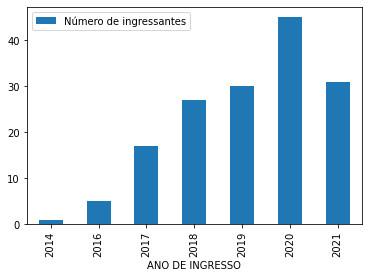

```python
ax = alunos_sta[['ANO DE INGRESSO', 'PERÍODO DE INGRESSO']].groupby('ANO DE INGRESSO').count().plot(kind='bar')
_ = ax.legend(['Número de ingressantes'])
```

# Analisando dados

```python
alunos_sta[['NOME DO ALUNO', 'ANO DE INGRESSO', 'PERÍODO DE INGRESSO']].groupby(['ANO DE INGRESSO', 'PERÍODO DE INGRESSO']).count()
```

| ANO DE INGRESSO | PERÍODO DE INGRESSO | NOME DO ALUNO |
| --- | --- | --- |
| 2014 | 2º Semestre | 1 |
| 2016 | 1º Semestre | 5 |
| 2017 | 1º Semestre | 17 |
| 2018 | 1º Semestre | 27 |
| 2019 | 1º Semestre | 27 |
|  | 2º Semestre | 3 |
| 2020 | 1º Semestre | 44 |
|  | 2º Semestre | 1 |
| 2021 | 1º Semestre | 31 |

# Analisando dados

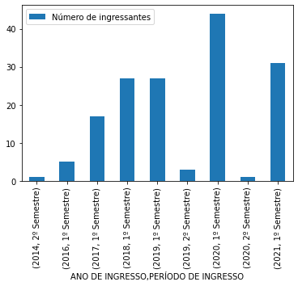

```python
ax = alunos_sta[['NOME DO ALUNO', 'ANO DE INGRESSO', 'PERÍODO DE INGRESSO']].groupby(['ANO DE INGRESSO', 'PERÍODO DE INGRESSO']).count().plot.bar('')
_ = ax.legend(['Número de ingressantes'])
```

# Introdução à biblioteca Pandas

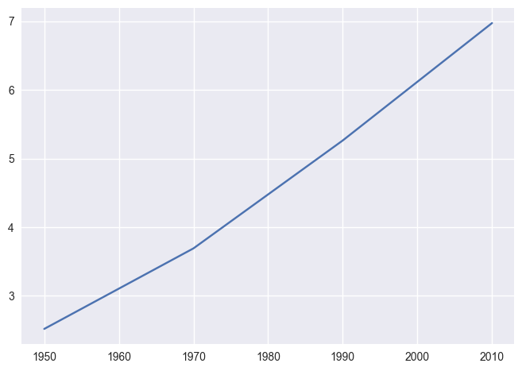

```python
import matplotlib.pyplot as plt

ano = [1950, 1970, 1990, 2010]
populacao = [2.519, 3.692, 5.263, 6.972]
plt.plot(ano, populacao)

plt.show()
```

# Introdução à biblioteca Pandas

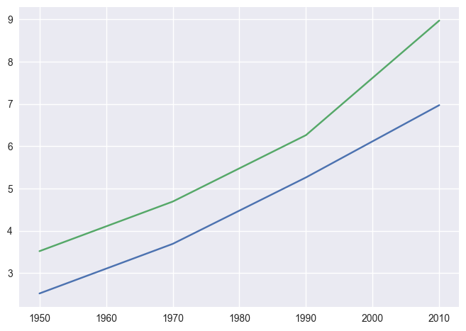

```python
import matplotlib.pyplot as plt

ano = [1950, 1970, 1990, 2010]
populacao1 = [2.519, 3.692, 5.263, 6.972]
populacao2 = [3.519, 4.692, 6.263, 8.972]
plt.plot(ano, populacao1)
plt.plot(ano, populacao2)
plt.style.use('seaborn')
plt.show()
```

# Introdução à biblioteca Pandas

```python
print(plt.style.available)
```

[output not shown]

```python
import pandas as pd
import matplotlib.pyplot as plt

df = pd.read_csv('microdados_ed_basica_2021.csv', sep = ";",encoding = "ISO-8859-1",nrows = 300)

df.head()
```

|  | NU_ANO_CENSO | NO_REGIAO | CO_REGIAO | NO_UF | SG_UF | CO_UF | NO_MUNICIPIO | CO_MUNICIPIO | NO_MESORREGIAO | CO_MESORREGIAO | ... | QT_TUR_FUND_AF | QT_TUR_MED | QT_TUR_PROF | QT_TUR_PROF_TEC | QT_TUR_EJA | QT_TUR_EJA_FUND | QT_TUR_EJA_MED | QT_TUR_ESP | QT_TUR_ESP_CC | QT_TUR_ESP_CE |
| --- | --- | --- | --- | --- | --- | --- | --- | --- | --- | --- | --- | --- | --- | --- | --- | --- | --- | --- | --- | --- | --- |
| 0 | 2021 | Norte | 1 | Rondônia | RO | 11 | Alta Floresta D'Oeste | 1100015 | Leste Rondoniense | 1102 | ... | 0.0 | 0.0 | 0.0 | 0.0 | 0.0 | 0.0 | 0.0 | 0.0 | 0.0 | 0.0 |
| 1 | 2021 | Norte | 1 | Rondônia | RO | 11 | Alta Floresta D'Oeste | 1100015 | Leste Rondoniense | 1102 | ... | 0.0 | 0.0 | 0.0 | 0.0 | 11.0 | 7.0 | 4.0 | 5.0 | 5.0 | 0.0 |
| 2 | 2021 | Norte | 1 | Rondônia | RO | 11 | Alta Floresta D'Oeste | 1100015 | Leste Rondoniense | 1102 | ... | 1.0 | 0.0 | 0.0 | 0.0 | 0.0 | 0.0 | 0.0 | 0.0 | 0.0 | 0.0 |
| 3 | 2021 | Norte | 1 | Rondônia | RO | 11 | Alta Floresta D'Oeste | 1100015 | Leste Rondoniense | 1102 | ... | 5.0 | 0.0 | 0.0 | 0.0 | 0.0 | 0.0 | 0.0 | 3.0 | 3.0 | 0.0 |
| 4 | 2021 | Norte | 1 | Rondônia | RO | 11 | Alta Floresta D'Oeste | 1100015 | Leste Rondoniense | 1102 | ... | 5.0 | 0.0 | 0.0 | 0.0 | 0.0 | 0.0 | 0.0 | 2.0 | 2.0 | 0.0 |

5 rows × 370 columns